# Reproducible Research: Peer Assessment 2 – Analysis of Storm Events that Cause the Most Economic and Population Health Damage in the United States Between 1950-2011

A. Yeh

July 26, 2015

## Synopsis

The following report is an analysis of U.S. storm data collected by the U.S. National Oceanic and Atmospheric Administration’s (NOAA) between the years of 1950-2011. The purpose of this analysis is to address the following two questions:

1. Across the United States, which types of storm events are most harmful with respect to population health?
2. Across the United States, which types of events have the greatest economic consequences?

Data processing and analyses steps are listed below. We conclude from this analysis that in terms of population health, tornadoes cause the most human fatalities and injuries among the 48 storm event categories. In terms of economic consequences, we conclude that flooding causes the most property damage, and drought causes the most crop damage.

## Load Data

```r
if(!is.element("repdata_data_StormData.csv.bz2", list.files())) {
        URL <- "https://d396qusza40orc.cloudfront.net/repdata%2Fdata%2FStormData.csv.bz2"
        download.file(URL, "./repdata_data_StormData.csv.bz2", method="curl")
}

if(!exists("data")) {
        data <- read.csv("./repdata_data_StormData.csv.bz2")
}
```

## Load Libraries

Check if required packages are installed. If not, install package before loading libraries.

```r
## Check if dplyr package is installed.
if(!is.element("dplyr", installed.packages()[,1])) {
        install.packages("dplyr")
}
library(dplyr)
```

```r
## Check if ggplot2 package is installed.
if(!is.element("ggplot2", installed.packages()[,1])) {
        install.packages("ggplot2")
}
library(ggplot2)

## Check if knitr package is installed.
if(!is.element("knitr", installed.packages()[,1])) {
        install.packages("knitr")
}
library(knitr)

## Check if reshape2 package is installed.
if(!is.element("reshape2", installed.packages()[,1])) {
        install.packages("reshape2")
}
library(reshape2)
```

Set global option so that all code is output.

```r
opts_chunk$set(echo=TRUE)
```

## Data Processing

#### Subsetting Data

First take a look at the variables of the data set.

```r
str(data)
```

```
## 'data.frame':    902297 obs. of  37 variables:
##  $ STATE__   : num  1 1 1 1 1 1 1 1 1 1 ...
##  $ BGN_DATE  : Factor w/ 16335 levels "1/1/1966 0:00:00",..: 6523 6523 4242 11116 2224 2224 2260 383 3980 3980 ...
##  $ BGN_TIME  : Factor w/ 3608 levels "00:00:00 AM",..: 272 287 2705 1683 2584 3186 242 1683 3186 3186 ...
##  $ TIME_ZONE : Factor w/ 22 levels "ADT","AKS","AST",..: 7 7 7 7 7 7 7 7 7 7 ...
##  $ COUNTY    : num  97 3 57 89 43 77 9 123 125 57 ...
##  $ COUNTYNAME: Factor w/ 29601 levels "","5NM E OF MACKINAC BRIDGE TO PRESQUE ISLE LT MI",..: 13513 1873 4598 10592 4372 10094 1973 23873 24418 4598 ...
##  $ STATE     : Factor w/ 72 levels "AK","AL","AM",..: 2 2 2 2 2 2 2 2 2 2 ...
##  $ EVTYPE    : Factor w/ 985 levels "   HIGH SURF ADVISORY",..: 834 834 834 834 834 834 834 834 834 834 ...
##  $ BGN_RANGE : num  0 0 0 0 0 0 0 0 0 0 ...
##  $ BGN_AZI   : Factor w/ 35 levels "","  N"," NW",..: 1 1 1 1 1 1 1 1 1 1 ...
##  $ BGN_LOCATI: Factor w/ 54429 levels ""," Christiansburg",..: 1 1 1 1 1 1 1 1 1 1 ...
##  $ END_DATE  : Factor w/ 6663 levels "","1/1/1993 0:00:00",..: 1 1 1 1 1 1 1 1 1 1 ...
##  $ END_TIME  : Factor w/ 3647 levels ""," 0900CST",..: 1 1 1 1 1 1 1 1 1 1 ...
##  $ COUNTY_END: num  0 0 0 0 0 0 0 0 0 0 ...
```

[output cut: 23 more lines]

The impact of storm events (as indicated in the EVTYPE variable) on population health is measured by the number of human fatalities and injuries (as indicated in the FATALITIES and INJURIES variables), and the economic damage caused by storm events is measured by the property and crop damage (as indicated in the PROPDMG and CROPDMG variables).

In a first pass at subsetting the data, we will include only rows where there are fatalities, injuries, property damage, or crop damage.

```r
attach(data)
data_subset <- data[data$FATALITIES > 0 | data$INJURIES > 0 | data$PROPDMG > 0 | data$CROPDMG > 0,]
```

#### Calculating Property Damage

In addition to the PROPDMG and CROPDMG variables, the dataset contains the variables PROPDMGEXP and CROPDMGEXP, the values of which are factors to be multipled with the PROPDMG and CROPDMG values to obtain the actual property and crop damage values.

Check what’s in the property damage exponent column.

```r
unique(PROPDMGEXP)
```

```
##  [1] K M   B m + 0 5 6 ? 4 2 3 h 7 H - 1 8
## Levels:  - ? + 0 1 2 3 4 5 6 7 8 B h H K m M
```

Convert PROPDMGEXP into corresponding number and enter that into a new column PropDmgMultiplier. These conversion factors were based on a detailed analysis of these factors found at this [link](https://rstudio-pubs-static.s3.amazonaws.com/58957_37b6723ee52b455990e149edde45e5b6.html).

```r
attach(data_subset)
data_subset$PropDmgMultiplier[PROPDMGEXP == "H" | PROPDMGEXP == "h"] <- 1e+02
data_subset$PropDmgMultiplier[PROPDMGEXP == "K" | PROPDMGEXP == "k"] <- 1e+03
data_subset$PropDmgMultiplier[PROPDMGEXP == "M" | PROPDMGEXP == "m"] <- 1e+06
data_subset$PropDmgMultiplier[PROPDMGEXP == "B" | PROPDMGEXP == "b"] <- 1e+09
data_subset$PropDmgMultiplier[PROPDMGEXP == "0"] <- 10
data_subset$PropDmgMultiplier[PROPDMGEXP == "1"] <- 10
data_subset$PropDmgMultiplier[PROPDMGEXP == "2"] <- 10
data_subset$PropDmgMultiplier[PROPDMGEXP == "3"] <- 10
data_subset$PropDmgMultiplier[PROPDMGEXP == "4"] <- 10
data_subset$PropDmgMultiplier[PROPDMGEXP == "5"] <- 10
data_subset$PropDmgMultiplier[PROPDMGEXP == "6"] <- 10
data_subset$PropDmgMultiplier[PROPDMGEXP == "7"] <- 10
data_subset$PropDmgMultiplier[PROPDMGEXP == "8"] <- 10
data_subset$PropDmgMultiplier[PROPDMGEXP == ""] <- 0
data_subset$PropDmgMultiplier[PROPDMGEXP == "?"] <- 0
data_subset$PropDmgMultiplier[PROPDMGEXP == "+"] <- 1
data_subset$PropDmgMultiplier[PROPDMGEXP == "-"] <- 0
```

Calculate property damage for each event by multiplying PROPDMG times PropDmgMultiplier and enter into new column PropDmgFinal.

```r
data_subset$PropDmgFinal <- data_subset$PROPDMG * data_subset$PropDmgMultiplier
```

#### Calculating Crop Damage

Do the same for crop damage as was done for property damage in above section.

Check what’s in the crop damage exponent column.

```r
unique(CROPDMGEXP)
```

```
## [1]   M K m B ? 0 k
## Levels:  ? 0 2 B k K m M
```

Convert CROPDMGEXP into correpsonding number and enter that into a new column CropDmgMultiplier

```r
data_subset$CropDmgMultiplier[CROPDMGEXP == "K" | CROPDMGEXP == "k"] <- 1e+03
data_subset$CropDmgMultiplier[CROPDMGEXP == "M" | CROPDMGEXP == "m"] <- 1e+06
data_subset$CropDmgMultiplier[CROPDMGEXP == "B"] <- 1e+09
data_subset$CropDmgMultiplier[CROPDMGEXP == "0"] <- 10
data_subset$CropDmgMultiplier[CROPDMGEXP == "2"] <- 10
data_subset$CropDmgMultiplier[CROPDMGEXP == ""] <- 0
data_subset$CropDmgMultiplier[PROPDMGEXP == "?"] <- 0
```

Calculate crop damage for each event by multiplying CROPDMG times CropDmgMultiplier and enter into new column CropDmgFinal.

```r
data_subset$CropDmgFinal <- data_subset$CROPDMG * data_subset$CropDmgMultiplier
```

#### Summing totals of fatalities, injuries, property damage, and crop damage over storm event types.

Reshape the data so that the total number of fatalities, injuries, property damage, and crop damage can be summed over all of the storm event types.

```r
data_subset_melt <- melt(data_subset, id = "EVTYPE", measure.vars = c("FATALITIES", "INJURIES", "PropDmgFinal", "CropDmgFinal"))

data_subset_dcast <- dcast(data_subset_melt, EVTYPE ~ variable, sum)
```

#### Group event types (in EVTYPE column) into one of 48 storm data event categories

Check the different event types in the data set.

```r
unique(data_subset_dcast$EVTYPE)
```

```
##   [1]    HIGH SURF ADVISORY           FLASH FLOOD
##   [3]  TSTM WIND                      TSTM WIND (G45)
##   [5] ?                              AGRICULTURAL FREEZE
##   [7] APACHE COUNTY                  ASTRONOMICAL HIGH TIDE
##   [9] ASTRONOMICAL LOW TIDE          AVALANCE
##  [11] AVALANCHE                      Beach Erosion
##  [13] BLACK ICE                      BLIZZARD
##  [15] BLIZZARD/WINTER STORM          BLOWING DUST
##  [17] blowing snow                   BLOWING SNOW
##  [19] BREAKUP FLOODING               BRUSH FIRE
##  [21] COASTAL  FLOODING/EROSION      COASTAL EROSION
##  [23] Coastal Flood                  COASTAL FLOOD
##  [25] Coastal Flooding               COASTAL FLOODING
##  [27] COASTAL FLOODING/EROSION       Coastal Storm
##  [29] COASTAL STORM                  COASTAL SURGE
```

[output cut: 230 more lines]

As can be seen above, there are currently a total of 488 storm event types in this data subset. This far exceeds the 48 event types that are officially listed in the Storm Data Event Table 2.1.1 that can be found at this [link](https://d396qusza40orc.cloudfront.net/repdata%2Fpeer2_doc%2Fpd01016005curr.pdf). This is a result of many duplicates, alternative naming/spelling, and mis-spellings of the storm event types in the EVTYPE column. The following section groups these 488 storm event types into one of the 48 listed categories. Event types for which a category could not be determined were placed in a category called ‘Other’.

Convert all EVTYPE’s to upper case since some of the EVTYPE’s are in lower case.

```r
data_subset_dcast$EVTYPE <- toupper(data_subset_dcast$EVTYPE)
```

```r
## Astronomical Low Tide
astronimical_low_tide <- grep('^ASTRONOMICAL LOW TIDE', data_subset_dcast$EVTYPE, value = TRUE)
data_subset_dcast$EventCategory[data_subset_dcast$EVTYPE %in% astronimical_low_tide] <- "Astronomical Low Tide"

## Avalanche
avalanche <- grep('^AVALANC', data_subset_dcast$EVTYPE, value = TRUE)
data_subset_dcast$EventCategory[data_subset_dcast$EVTYPE %in% avalanche] <- "Avalanche"

## Blizzard
blizzard <- grep('^BLIZZARD|GROUND BLIZZARD', data_subset_dcast$EVTYPE, value = TRUE)
data_subset_dcast$EventCategory[data_subset_dcast$EVTYPE %in% blizzard] <- "Blizzard"

## Coastal Flood
coastal_flood <- grep('COASTAL', data_subset_dcast$EVTYPE, value = TRUE)
data_subset_dcast$EventCategory[data_subset_dcast$EVTYPE %in% coastal_flood] <- "Coastal Flood"

## Cold/Wind Chill
cold_wind_chill <- intersect(grep('^COLD$|^COLD|RECORD COLD|UNSEASONABLY COLD|LOW TEMPERATURE|HYPOTHERMIA|HYPERTHERMIA|EXTENDED COLD|COOL AND WET|UNSEASONABLE COLD',
        data_subset_dcast$EVTYPE, value = TRUE,  ignore.case = TRUE), grep('COLD AIR TORNADO', data_subset_dcast$EVTYPE, invert = TRUE, value = TRUE))
data_subset_dcast$EventCategory[data_subset_dcast$EVTYPE %in% cold_wind_chill] <- "Cold/Wind Chill"

## Dense Fog
dense_fog <- grep('DENSE FOG|^FOG$', data_subset_dcast$EVTYPE, value = TRUE)
data_subset_dcast$EventCategory[data_subset_dcast$EVTYPE %in% dense_fog] <- "Dense Fog"

## Dense Smoke
dense_smoke <- grep('DENSE SMOKE', data_subset_dcast$EVTYPE, value = TRUE)
data_subset_dcast$EventCategory[data_subset_dcast$EVTYPE %in% dense_smoke] <- "Dense Smoke"

## Drought
drought <- grep('DROUGHT', data_subset_dcast$EVTYPE, value = TRUE)
data_subset_dcast$EventCategory[data_subset_dcast$EVTYPE %in% drought] <- "Drought"

## Dust Devil
dust_devil <- grep("DUST DEVIL", data_subset_dcast$EVTYPE, value = TRUE)
data_subset_dcast$EventCategory[data_subset_dcast$EVTYPE %in% dust_devil] <- "Dust Devil"

## Dust Storm
dust_storm <- grep('DUST STORM|DUST$', data_subset_dcast$EVTYPE, value = TRUE)
data_subset_dcast$EventCategory[data_subset_dcast$EVTYPE %in% dust_storm] <- "Dust Storm"

## Excessive Heat
excessive_heat <- intersect(grep('EXCESSIVE HEAT|EXTREME HEAT|RECORD HEAT|UNSEASONABLY WARM', data_subset_dcast$EVTYPE, value = TRUE),
        grep('DROUGHT/EXCESSIVE HEAT', data_subset_dcast$EVTYPE, invert = TRUE, value = TRUE))
data_subset_dcast$EventCategory[data_subset_dcast$EVTYPE %in% excessive_heat] <- "Excessive Heat"

## Extreme Cold
extreme_cold <- grep('EXTREME COLD|EXTREME WIND|SNOW/ BITTER COLD', data_subset_dcast$EVTYPE, value = TRUE)
data_subset_dcast$EventCategory[data_subset_dcast$EVTYPE %in% extreme_cold] <- "Extreme Cold/Wind Chill"

## Flash Flood
flash_flood <- grep('FLASH|LANDSLIDE|MUDSLIDE|MUD SLIDE|RAPIDLY RISING WATER', data_subset_dcast$EVTYPE, value = TRUE)
data_subset_dcast$EventCategory[data_subset_dcast$EVTYPE %in% flash_flood] <- "Flash Flood"

## Flood
flood <- intersect(grep('FLOOD|URBAN/SML STREAM FLD|URBAN*.*SMALL', data_subset_dcast$EVTYPE, value = TRUE),
        grep('COASTAL|LAKE *.* FLOOD|FLASH|^HEAVY RAIN|^HEAVY SNOW|THUNDERSTORM WINDS',
        data_subset_dcast$EVTYPE, invert = TRUE, value = TRUE))
data_subset_dcast$EventCategory[data_subset_dcast$EVTYPE %in% flood] <- "Flood"

## Freezing Fog
freezing_fog <- grep('FOG AND COLD TEMPERATURES|FREEZING FOG', data_subset_dcast$EVTYPE, value = TRUE)
data_subset_dcast$EventCategory[data_subset_dcast$EVTYPE %in% freezing_fog] <- "Freezing Fog"

## Frost/Freeze
frost_freeze <- grep('FROST|FREEZE', data_subset_dcast$EVTYPE, value = TRUE)
data_subset_dcast$EventCategory[data_subset_dcast$EVTYPE %in% frost_freeze] <- "Frost/Freeze"

## Funnel Cloud
funnel_cloud <- grep('FUNNEL CLOUD', data_subset_dcast$EVTYPE, value = TRUE)
data_subset_dcast$EventCategory[data_subset_dcast$EVTYPE %in% funnel_cloud] <- "Funnel Cloud"

## Hail
hail <- grep('^HAIL|SMALL HAIL', data_subset_dcast$EVTYPE, value = TRUE)
data_subset_dcast$EventCategory[data_subset_dcast$EVTYPE %in% hail] <- "Hail"

## Heat
heat <- intersect(grep('^HEAT|WARM WEATHER', data_subset_dcast$EVTYPE, value = TRUE),
        grep('DROUGHT', data_subset_dcast$EVTYPE, invert = TRUE, value = TRUE))
data_subset_dcast$EventCategory[data_subset_dcast$EVTYPE %in% heat] <- "Heat"

## Heavy Rain
heavy_rain_evtype <- c('^HEAVY RAIN|^RAIN|EXCESSIVE RAINFALL|HEAVY PRECIPITATION|RECORD RAINFALL|EXCESSIVE WETNESS|HEAVY SHOWER|HVY RAIN|TORRENTIAL RAINFALL|UNSEASONAL RAIN')
heavy_rain <- grep(heavy_rain_evtype, data_subset_dcast$EVTYPE, value = TRUE)
data_subset_dcast$EventCategory[data_subset_dcast$EVTYPE %in% heavy_rain] <- "Heavy Rain"

## Heavy Snow
heavy_snow <- intersect(grep('HEAVY SNOW|^SNOW$|EXCESSIVE SNOW|RECORD SNOW|SNOW/COLD|HEAVY SNOW AND HIGH WINDS|SNOW SQUALL',
        data_subset_dcast$EVTYPE, value = TRUE), grep('^HIGH WIND', data_subset_dcast$EVTYPE, invert = TRUE, value = TRUE))
data_subset_dcast$EventCategory[data_subset_dcast$EVTYPE %in% heavy_snow] <- "Heavy Snow"

## High Surf
high_surf <- grep('HIGH SURF|^HEAVY SURF$|ROUGH SURF|HAZARDOUS SURF|HEAVY SURF AND WIND', data_subset_dcast$EVTYPE, value = TRUE)
data_subset_dcast$EventCategory[data_subset_dcast$EVTYPE %in% high_surf] <- "High Surf"

## High Wind
high_wind <- grep('^HIGH WIND|SNOW/HIGH WINDS|NON*.*TSTM WIND|WHIRLWIND|HIGH  WINDS|SEVERE TURBULENCE', data_subset_dcast$EVTYPE, value = TRUE)
data_subset_dcast$EventCategory[data_subset_dcast$EVTYPE %in% high_wind] <- "High Wind"

## Hurricane
hurricane <- grep('HURRICANE|TYPHOON', data_subset_dcast$EVTYPE, value = TRUE)
data_subset_dcast$EventCategory[data_subset_dcast$EVTYPE %in% hurricane] <- "Hurricane/Typhoon"

## Ice Storm
ice_storm <- grep('^ICE|GLAZE|ICY|SNOW AND ICE|SNOW/ICE STORM', data_subset_dcast$EVTYPE, value = TRUE)
data_subset_dcast$EventCategory[data_subset_dcast$EVTYPE %in% ice_storm] <- "Ice Storm"

## Lake Effect Snow
lake_effect_snow <- grep('LAKE *.* SNOW', data_subset_dcast$EVTYPE, value = TRUE)
data_subset_dcast$EventCategory[data_subset_dcast$EVTYPE %in% lake_effect_snow] <- "Lake Effect Snow"

## Lakeshore Flood
lakeshore_flood <- grep('LAKE *.* FLOOD', data_subset_dcast$EVTYPE, value = TRUE)
data_subset_dcast$EventCategory[data_subset_dcast$EVTYPE %in% lakeshore_flood] <- "Lakeshore Flood"

## Lightning
lightning <- grep('^LIGHTNING|LIGHTING|LIGNTNING', data_subset_dcast$EVTYPE, value = TRUE)
data_subset_dcast$EventCategory[data_subset_dcast$EVTYPE %in% lightning] <- "Lightning"

## Marine Hail
marine_hail <- grep('MARINE HAIL', data_subset_dcast$EVTYPE, value = TRUE)
data_subset_dcast$EventCategory[data_subset_dcast$EVTYPE %in% marine_hail] <- "Marine Hail"

## Marine High Wind
marine_high_wind <- grep('MARINE HIGH WIND', data_subset_dcast$EVTYPE, value = TRUE)
data_subset_dcast$EventCategory[data_subset_dcast$EVTYPE %in% marine_high_wind] <- "Marine High Wind"

## Marine Strong Wind
marine_strong_wind <- grep('MARINE STRONG|ROUGH SEAS', data_subset_dcast$EVTYPE, value = TRUE)
data_subset_dcast$EventCategory[data_subset_dcast$EVTYPE %in% marine_strong_wind] <- "Marine Strong Wind"

## Marine Thunderstorm Wind
marine_thunderstorm_wind <- grep('MARINE T*.*M WIND', data_subset_dcast$EVTYPE, value = TRUE)
data_subset_dcast$EventCategory[data_subset_dcast$EVTYPE %in% marine_thunderstorm_wind] <- "Marine Thunderstorm Wind"

## Rip Current
rip_current <- grep('RIP CURRENT', data_subset_dcast$EVTYPE, value = TRUE)
data_subset_dcast$EventCategory[data_subset_dcast$EVTYPE %in% rip_current] <- "Rip Current"

## Seiche
seiche <- grep('SEICHE', data_subset_dcast$EVTYPE, value = TRUE)
data_subset_dcast$EventCategory[data_subset_dcast$EVTYPE %in% seiche] <- "Seiche"

## Sleet
sleet <- intersect(grep('SLEET|FREEZING RAIN|FREEZING DRIZZLE|BLACK ICE', data_subset_dcast$EVTYPE, value = TRUE),
        grep('^HEAVY SNOW', data_subset_dcast$EVTYPE, invert = TRUE, value = TRUE))
data_subset_dcast$EventCategory[data_subset_dcast$EVTYPE %in% sleet] <- "Sleet"

## Storm Surge/Tide
storm_surge_tide <- intersect(grep('SURGE|TIDE|ASTRONOMICAL HIGH TIDE|HIGH SEAS|HIGH WATER|HEAVY SEAS|HIGH SWELLS|HIGH WAVES|HEAVY SWELLS',
        data_subset_dcast$EVTYPE, value = TRUE), grep('^ASTRONOMICAL LOW TIDE', data_subset_dcast$EVTYPE, invert = TRUE, value = TRUE))
data_subset_dcast$EventCategory[data_subset_dcast$EVTYPE %in% storm_surge_tide] <- "Storm Surge/Tide"

## Strong Wind
strong_winds <- grep('^STRONG WIND|^ICE/STRONG WINDS|^WIND|GUSTY|NON-SEVERE WIND DAMAGE|GRADIENT WIND', data_subset_dcast$EVTYPE, value = TRUE)
data_subset_dcast$EventCategory[data_subset_dcast$EVTYPE %in% strong_winds] <- "Strong Wind"

## Thunderstorm Wind
thunderstorm <- intersect(grep('THUNDER|TSTM|MICROBURST|TUNDER|THUDERSTORM|STORM FORCE WINDS|THUNERSTORM|THUNDEERSTORM|MIRCOBURST|GUSTNADO|DOWNBURST',
        data_subset_dcast$EVTYPE, value = TRUE), grep("NON|MARINE|^FLASH", data_subset_dcast$EVTYPE, invert = TRUE, value = TRUE))
data_subset_dcast$EventCategory[data_subset_dcast$EVTYPE %in% thunderstorm] <- "Thunderstorm Wind"

## Tornado
tornado <- intersect(grep('TORNADO|TORNDAO', data_subset_dcast$EVTYPE, value = TRUE),
        grep("WATERSPOUT", data_subset_dcast$EVTYPE, invert = TRUE, value = TRUE))
data_subset_dcast$EventCategory[data_subset_dcast$EVTYPE %in% tornado] <- "Tornado"

## Tropical Depression
tropical_depression <- grep('TROPICAL DEPRESSION', data_subset_dcast$EVTYPE, value = TRUE)
data_subset_dcast$EventCategory[data_subset_dcast$EVTYPE %in% tropical_depression] <- "Tropical Depression"

## Tropical Storm
tropical_storm <- grep('TROPICAL STORM', data_subset_dcast$EVTYPE, value = TRUE)
data_subset_dcast$EventCategory[data_subset_dcast$EVTYPE %in% tropical_storm] <- "Tropical Storm"

## Tsunami
tsunami <- grep('TSUNAMI', data_subset_dcast$EVTYPE, value = TRUE)
data_subset_dcast$EventCategory[data_subset_dcast$EVTYPE %in% tsunami] <- "Tsunami"

## Volcanic Ash
volcanic_ash <- grep('VOLCANIC ASH', data_subset_dcast$EVTYPE, value = TRUE)
data_subset_dcast$EventCategory[data_subset_dcast$EVTYPE %in% volcanic_ash] <- "Volcanic Ash"

## Waterspout
waterspout <- grep('WATERSPOUT', data_subset_dcast$EVTYPE, value = TRUE)
data_subset_dcast$EventCategory[data_subset_dcast$EVTYPE %in% waterspout] <- "Waterspout"

## Wildfire
wildfire <- grep('FIRE', data_subset_dcast$EVTYPE, value = TRUE)
data_subset_dcast$EventCategory[data_subset_dcast$EVTYPE %in% wildfire] <- "Wildfire"

## Winter Storm
winter_storm <- grep('^WINTER STORM|HEAVY MIX', data_subset_dcast$EVTYPE, value = TRUE)
data_subset_dcast$EventCategory[data_subset_dcast$EVTYPE %in% winter_storm] <- "Winter Storm"

## Winter Weather
winter_weather <- grep('WINTER WEATHER|WINTRY MIX|BLOWING SNOW|FALLING SNOW/ICE|LIGHT SNOW|LATE SEASON SNOW|SNOW/ ICE|^SNOW/ICE$',
        data_subset_dcast$EVTYPE, value = TRUE)
data_subset_dcast$EventCategory[data_subset_dcast$EVTYPE %in% winter_weather] <- "Winter Weather"

## Other
other <- grep('BEACH EROSION|DAM BREAK|DROWNING|FREEZING SPRAY|^HIGH$|LANDSLUMP|LANDSPOUT|MARINE ACCIDENT|MARINE MISHAP|MIXED PRECIP|^OTHER$|ROCK SLIDE|ROGUE WAVE|SNOW ACCUMULATION', data_subset_dcast$EVTYPE, value = TRUE)
data_subset_dcast$EventCategory[data_subset_dcast$EVTYPE %in% other] <- "Other"
```

#### Create summary dataframe

Create a new summary dataframe that has 48 storm event categories and the corresponding economic and population health impact.

```r
data_summary <- data_subset_dcast
```

Remove old EVTYPE column.

```r
data_summary$EVTYPE <- NULL
```

Reorder columns so that EventCategory is the first column in the dataframe.

```r
colnames(data_summary)
```

```
## [1] "FATALITIES"    "INJURIES"      "PropDmgFinal"  "CropDmgFinal"
## [5] "EventCategory"
```

```r
data_summary <- data_summary[,c(5,1,2,3,4)]
```

Rename columns

```r
names(data_summary) <- c("EventCategory", "Fatalities", "Injuries", "PropertyDamage", "CropDamage")
```

Sum fatalities, injuries, property damage, and crop damage for each of 48 storm event categories

```r
data_summary <- melt(data_summary, id = "EventCategory", measure.vars = c("Fatalities", "Injuries", "PropertyDamage", "CropDamage"))
data_summary <- dcast(data_summary, EventCategory ~ variable, sum)
```

Sum number of fatalities and injuries to determine total population health impact and sum property and crop damages to determine total economic costs

```r
data_summary$PopulationHealth <- rowSums(data_summary[,c(2:3)])
data_summary$EconomicCosts <- rowSums(data_summary[,c(4:5)])
```

Reorder columns

```r
data_summary <- data_summary[,c(1,2,3,6,4,5,7)]
```

#### Rank storm event categories based on population health impact

48 storm event categories ranked according to number of fatalities

```r
fatalities_ranked <- data_summary[order(-data_summary$Fatalities), c(1,2)] %>% mutate(Rank = dense_rank(desc(Fatalities)))
fatalities_ranked <- fatalities_ranked[,c(3,1,2)]
```

Top 10 storm event categories causing the most number of fatalities

```r
fatalities_top10 <- fatalities_ranked[1:10,]
```

48 storm event categories ranked according to number of injuries

```r
injuries_ranked <- data_summary[order(-data_summary$Injuries), c(1,3)] %>% mutate(Rank = dense_rank(desc(Injuries)))
injuries_ranked <- injuries_ranked[,c(3,1,2)]
```

Top 10 storm event categories causing the most number of injuries

```r
injuries_top10 <- injuries_ranked[1:10,]
```

48 storm event categories ranked according to their impact on total population health (i.e., fatalities + injuries)

```r
pophealth_ranked <- data_summary[order(-data_summary$PopulationHealth), c(1:4)] %>% mutate(Rank = dense_rank(desc(PopulationHealth)))
pophealth_ranked <- pophealth_ranked[,c(5,1,2,3,4)]
```

Top 10 storm event categories causing the most impact on population health (fatalities + injuries)

```r
pophealth_top10 <- pophealth_ranked[1:10,]
```

#### Rank storm event categories based on economic costs impact

48 storm event categories ranked according to property damage

```r
propdmg_ranked <- data_summary[order(-data_summary$PropertyDamage), c(1,5)] %>% mutate(Rank = dense_rank(desc(PropertyDamage)))
propdmg_ranked <- propdmg_ranked[,c(3,1,2)]
```

Top 10 storm event categories causing the most property damage

```r
propdmg_top10 <- propdmg_ranked[1:10,]
```

48 storm event categories ranked according to crop damage

```r
cropdmg_ranked <- data_summary[order(-data_summary$CropDamage), c(1,6)] %>% mutate(Rank = dense_rank(desc(CropDamage)))
cropdmg_ranked <- cropdmg_ranked[,c(3,1,2)]
```

Top 10 storm event categories causing the most crop damage

```r
cropdmg_top10 <- cropdmg_ranked[1:10,]
```

48 storm event categories ranked according to total economic costs

```r
econcosts_ranked <- data_summary[order(-data_summary$EconomicCosts), c(1,5:7)] %>% mutate(Rank = dense_rank(desc(EconomicCosts)))
econcosts_ranked <- econcosts_ranked[,c(5,1,2,3,4)]
```

Top 10 storm event categories causing the greatest economic costs

```r
econcosts_top10 <- econcosts_ranked[1:10,]
```

## Results

### Population Health Impact of Storm Events

#### Fatalities

The ranking of storm events that have caused human fatalities in the U.S. between 1950-2011 is listed in the following table:

```r
fatalities_ranked
```

```
##    Rank            EventCategory Fatalities
## 1     1                  Tornado       5658
## 2     2           Excessive Heat       2058
## 3     3                     Heat       1114
## 4     4              Flash Flood       1080
## 5     5                Lightning        817
## 6     6        Thunderstorm Wind        715
## 7     7              Rip Current        577
## 8     8                    Flood        512
## 9     9  Extreme Cold/Wind Chill        305
## 10   10                High Wind        294
## 11   11                Avalanche        225
## 12   12             Winter Storm        217
## 13   13          Cold/Wind Chill        178
## 14   14                High Surf        161
```

[output cut: 35 more lines]

#### Injuries

The ranking of storm events that have caused human injuries in the U.S. between 1950-2011 is listed in the following table:

```r
injuries_ranked
```

```
##    Rank            EventCategory Injuries
## 1     1                  Tornado    91364
## 2     2        Thunderstorm Wind     9539
## 3     3                    Flood     6874
## 4     4           Excessive Heat     6747
## 5     5                Lightning     5231
## 6     6                     Heat     2481
## 7     7                Ice Storm     2378
## 8     8              Flash Flood     1855
## 9     9                 Wildfire     1608
## 10   10                High Wind     1508
## 11   11                     Hail     1371
## 12   12             Winter Storm     1353
## 13   13        Hurricane/Typhoon     1333
## 14   14               Heavy Snow     1102
```

[output cut: 35 more lines]

#### Fatalities + Injuries

The top 10 storm events that have most impacted population health (fatalities + injuries) in the U.S. between 1950-2011 is listed in the following table:

```r
pophealth_top10
```

```
##    Rank     EventCategory Fatalities Injuries PopulationHealth
## 1     1           Tornado       5658    91364            97022
## 2     2 Thunderstorm Wind        715     9539            10254
## 3     3    Excessive Heat       2058     6747             8805
## 4     4             Flood        512     6874             7386
## 5     5         Lightning        817     5231             6048
## 6     6              Heat       1114     2481             3595
## 7     7       Flash Flood       1080     1855             2935
## 8     8         Ice Storm        112     2378             2490
## 9     9         High Wind        294     1508             1802
## 10   10          Wildfire         90     1608             1698
```

The results abvoe are summarized graphically in Figure 1 below.

#### Figure 1. Panel plots showing the population health damage that storm events have caused in the U.S. between 1950 and 2011

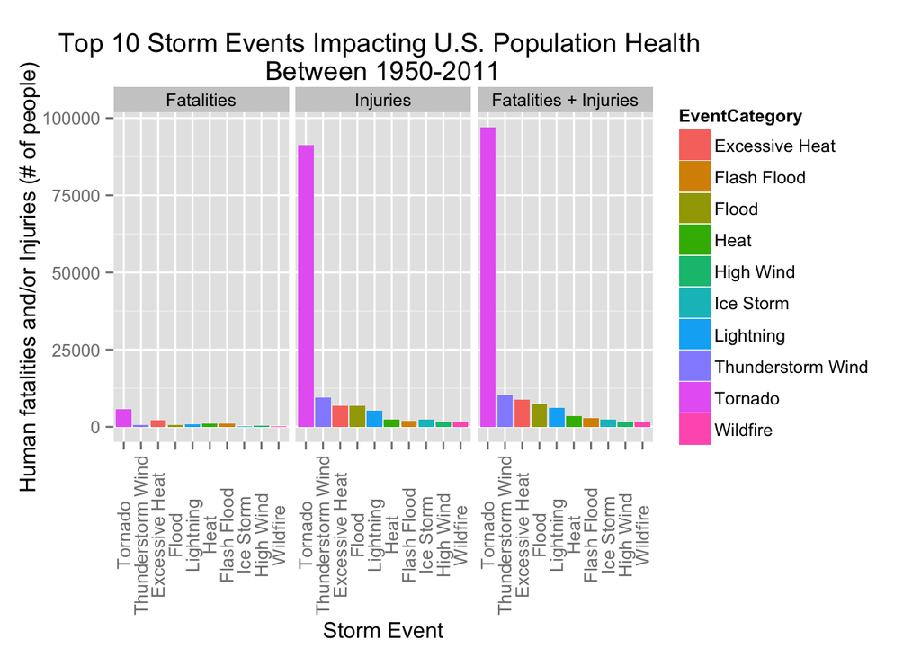

```r
pophealth_top10_melt <- melt(pophealth_top10, id.var = "EventCategory", measure.vars = c("Fatalities", "Injuries", "PopulationHealth"))
levels(pophealth_top10_melt$variable) <- c("Fatalities", "Injuries", "Fatalities + Injuries")

plot1 <- ggplot(pophealth_top10_melt, aes(x = reorder(EventCategory, -value), y = value))

print(plot1 + geom_bar(aes(fill = EventCategory), stat = "identity") +
              labs(title = "Top 10 Storm Events Impacting U.S. Population Health \nBetween 1950-2011", x = "Storm Event", y = "Human fatalities and/or Injuries (# of people)") + theme(axis.text.x = element_text(angle=90, size=10, vjust=0.5)) + facet_wrap(~ variable, ncol = 3))
```

### Economic Costs of Storm Events

#### Property Damage

The ranking of storm events that have caused property damage in the U.S. between 1950-2011 is listed in the following table:

```r
propdmg_ranked
```

```
##    Rank            EventCategory PropertyDamage
## 1     1                    Flood   150227444432
## 2     2        Hurricane/Typhoon    85356410010
## 3     3                  Tornado    58541934647
## 4     4         Storm Surge/Tide    47975191000
## 5     5              Flash Flood    17234607303
## 6     6                     Hail    15974542377
## 7     7        Thunderstorm Wind    10978175472
## 8     8                 Wildfire     8501628500
## 9     9           Tropical Storm     7714390550
## 10   10             Winter Storm     6750302260
## 11   11                High Wind     6005058745
## 12   12                Ice Storm     3970463060
## 13   13               Heavy Rain     3223349190
## 14   14                  Drought     1046306000
```

[output cut: 35 more lines]

#### Crop Damage

The ranking of storm events that have caused crop damage in the U.S. between 1950-2011 is listed in the following table:

```r
cropdmg_ranked
```

```
##    Rank            EventCategory  CropDamage
## 1     1                  Drought 13972621780
## 2     2                    Flood 10850941050
## 3     3        Hurricane/Typhoon  5516117800
## 4     4                Ice Storm  5027114300
## 5     5                     Hail  3046887800
## 6     6             Frost/Freeze  1997061000
## 7     7  Extreme Cold/Wind Chill  1330023000
## 8     8               Heavy Rain   947005800
## 9     9           Tropical Storm   694896000
## 10   10                High Wind   686321900
## 11   11           Excessive Heat   497412000
## 12   12                  Tornado   417462960
## 13   13                     Heat   407011500
## 14   14                 Wildfire   403281630
```

[output cut: 35 more lines]

#### Property + Crop Damage

The top 10 storm events that have cause the most damage in terms of property and crop damage combined in the U.S. between 1950-2011 is listed in the following table:

```r
econcosts_top10
```

```
##    Rank     EventCategory PropertyDamage  CropDamage EconomicCosts
## 1     1             Flood   150227444432 10850941050  161078385482
## 2     2 Hurricane/Typhoon    85356410010  5516117800   90872527810
## 3     3           Tornado    58541934647   417462960   58959397607
## 4     4  Storm Surge/Tide    47975191000      855000   47976046000
## 5     5              Hail    15974542377  3046887800   19021430177
## 6     6           Drought     1046306000 13972621780   15018927780
## 7     7         Ice Storm     3970463060  5027114300    8997577360
## 8     8          Wildfire     8501628500   403281630    8904910130
## 9     9    Tropical Storm     7714390550   694896000    8409286550
## 10   10      Winter Storm     6750302260    32444000    6782746260
```

The above results are summarized graphically in Figure 2 below.

#### Figure 2. Panel plots showing the economic damage that storm events have caused in the U.S. between 1950 and 2011

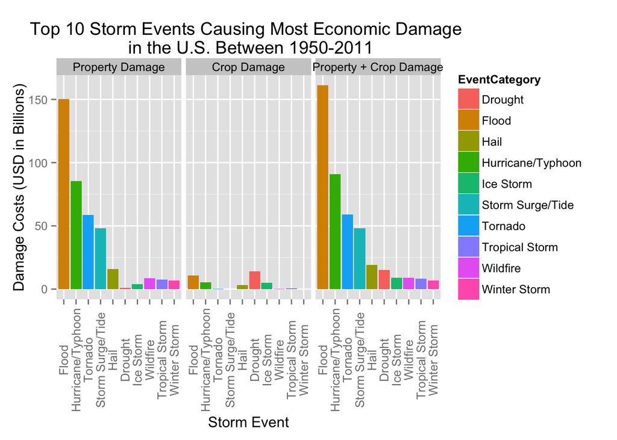

```r
econcosts_top10_melt <- melt(econcosts_top10, id.var = "EventCategory", measure.vars = c("PropertyDamage", "CropDamage", "EconomicCosts"))
levels(econcosts_top10_melt$variable) <- c("Property Damage", "Crop Damage", "Property + Crop Damage")

plot2 <- ggplot(econcosts_top10_melt, aes(x = reorder(EventCategory, -value), y = value/1e+09))

print(plot2 + geom_bar(aes(fill = EventCategory), stat = "identity") +
        labs(title = "Top 10 Storm Events Causing Most Economic Damage \n in the U.S. Between 1950-2011", x = "Storm Event", y = "Damage Costs (USD in Billions)") +
        theme(axis.text.x = element_text(angle=90, size=10, vjust=0.5)) +
        facet_wrap(~ variable, ncol = 3))
```

## Conclusions

In terms of economic costs, the storm event that has caused the most property damage over the years is flooding, followed by hurricanes, tornadoes, storm surges, and flash floods to round out the top five. And the storm event causing the most crop damage has been drought, followed by flooding, hurricanes, ice storms, and hail.